# The Analytics Edge (Final Exam)

Na Sai

May 21, 2015

# Final Exam

## Problem 1. Forecasting Airline Delays

On any given day, more than 87,000 flights take place in the United States alone. About one-third of these flights are commercial flights, operated by companies like United, American Airlines, and JetBlue. While about 80% of commercial flights take-off and land as scheduled, the other 20% suffer from delays due to various reasons. A certain number of delays are unavoidable, due to unexpected events, but some delays could hopefully be avoided if the factors causing delays were better understood and addressed.

In this problem, we’ll use a dataset of 9,381 flights that occured in June through August of 2014 between the three busiest US airports – Atlanta (ATL), Los Angeles (LAX), and Chicago (ORD) – to predict flight delays. The dataset AirlineDelay.csv includes the following 23 variables:

```r
Airlines <- read.csv("AirlineDelay.csv")
str(Airlines)
```

```
## 'data.frame':    9381 obs. of  23 variables:
##  $ Flight             : Factor w/ 6 levels "ATL-LAX","ATL-ORD",..: 4 4 4 4 4 4 4 4 4 4 ...
##  $ Carrier            : Factor w/ 8 levels "AirTran Airways",..: 2 2 2 2 2 2 2 2 2 2 ...
##  $ Month              : Factor w/ 3 levels "August","July",..: 3 3 3 3 3 3 3 3 3 3 ...
##  $ DayOfWeek          : Factor w/ 7 levels "Friday","Monday",..: 7 5 1 4 2 6 7 5 1 3 ...
##  $ NumPrevFlights     : int  1 1 2 1 1 1 1 2 1 1 ...
##  $ PrevFlightGap      : int  55 55 35 30 55 55 55 55 55 5 ...
##  $ HistoricallyLate   : num  0 0 0 0.25 0.2 ...
##  $ InsufficientHistory: int  1 1 1 0 0 0 0 0 0 0 ...
##  $ OriginInVolume     : num  1.05 1.02 1.03 1.09 1.04 ...
##  $ OriginOutVolume    : num  1.027 1.02 0.998 1.002 0.995 ...
##  $ DestInVolume       : num  0.99 0.961 0.991 0.97 0.988 ...
##  $ DestOutVolume      : num  0.987 0.99 1.001 1.036 0.986 ...
##  $ OriginPrecip       : int  0 0 0 0 0 0 0 0 0 0 ...
##  $ OriginAvgWind      : num  9.62 8.72 7.61 7.61 8.95 ...
##  $ OriginWindGust     : num  19.9 18.1 16.1 17 18.1 ...
##  $ OriginFog          : int  0 0 1 0 0 0 0 1 1 0 ...
##  $ OriginThunder      : int  0 0 0 0 0 0 0 0 0 0 ...
##  $ DestPrecip         : int  132 0 0 0 0 0 165 81 3 325 ...
##  $ DestAvgWind        : num  7.38 10.07 9.84 15.66 8.72 ...
##  $ DestWindGust       : num  16.1 23.9 18.1 32 17 ...
##  $ DestFog            : int  0 0 0 0 0 0 0 0 0 0 ...
##  $ DestThunder        : int  0 0 0 0 0 0 0 0 0 0 ...
##  $ TotalDelay         : int  25 0 0 0 0 10 64 70 0 139 ...
```

```r
# split sample
set.seed(15071)
spl <- sample(nrow(Airlines), 0.7*nrow(Airlines))
AirlinesTrain <- Airlines[spl,]
AirlinesTest <- Airlines[-spl,]
#How many observations are in the training set AirlinesTrain?
nrow(AirlinesTrain)
```

```
## [1] 6566
```

```r
#How many observations are in the testing set AirlinesTest?
nrow(AirlinesTest)
```

```
## [1] 2815
```

```r
#Build a linear regression model to predict "TotalDelay" using all of the other variables as independent variables. Use the training set to build the model.
Airlines.lm <- lm(TotalDelay~.,data = AirlinesTrain)
summary(Airlines.lm)
```

```
##
## Call:
## lm(formula = TotalDelay ~ ., data = AirlinesTrain)
##
## Residuals:
##    Min     1Q Median     3Q    Max
## -68.30 -16.77  -7.71   2.78 817.93
##
## Coefficients:
##                              Estimate Std. Error t value Pr(>|t|)
## (Intercept)                -45.055881  10.107693  -4.458 8.43e-06 ***
## FlightATL-ORD                4.379016   2.175661   2.013  0.04418 *
## FlightLAX-ATL                1.901867   1.967008   0.967  0.33364
## FlightLAX-ORD                5.660679  12.596163   0.449  0.65316
## FlightORD-ATL                6.303303   2.262117   2.786  0.00534 **
## FlightORD-LAX               11.006282  12.597601   0.874  0.38232
## CarrierAmerican Airlines    -5.724074  13.025146  -0.439  0.66034
## CarrierDelta Air Lines       0.355603   3.527356   0.101  0.91970
## CarrierExpressJet Airlines   7.142202   6.574938   1.086  0.27740
## CarrierSkyWest Airlines      5.527777   4.921477   1.123  0.26140
## CarrierSouthwest Airlines    0.241642   3.924019   0.062  0.95090
## CarrierUnited Airlines       1.148722  12.937041   0.089  0.92925
## CarrierVirgin America       -5.505712  13.222651  -0.416  0.67714
## MonthJuly                   -6.345533   1.279019  -4.961 7.18e-07 ***
## MonthJune                   -3.784569   1.333093  -2.839  0.00454 **
## DayOfWeekMonday             -0.810539   1.914973  -0.423  0.67212
## DayOfWeekSaturday           -4.506943   2.065833  -2.182  0.02917 *
## DayOfWeekSunday             -5.418356   1.944548  -2.786  0.00534 **
## DayOfWeekThursday            1.571501   1.937850   0.811  0.41742
## DayOfWeekTuesday            -4.206489   2.011211  -2.092  0.03652 *
## DayOfWeekWednesday           1.585338   1.953771   0.811  0.41715
## NumPrevFlights               1.563247   0.504670   3.098  0.00196 **
## PrevFlightGap                0.015831   0.008055   1.965  0.04940 *
## HistoricallyLate            47.913638   3.326901  14.402  < 2e-16 ***
## InsufficientHistory         13.510716   1.586589   8.516  < 2e-16 ***
## OriginInVolume               5.121318   4.874897   1.051  0.29350
## OriginOutVolume              6.682176   6.209972   1.076  0.28195
## DestInVolume                14.971479   6.439830   2.325  0.02011 *
## DestOutVolume                1.221879   2.268822   0.539  0.59021
## OriginPrecip                 0.019734   0.006278   3.143  0.00168 **
## OriginAvgWind               -0.656333   0.296051  -2.217  0.02666 *
## OriginWindGust               0.948098   0.130843   7.246 4.78e-13 ***
## OriginFog                   -0.239182   1.666246  -0.144  0.88586
## OriginThunder               -0.818011   3.184140  -0.257  0.79726
## DestPrecip                   0.036874   0.006381   5.778 7.90e-09 ***
## DestAvgWind                 -0.282348   0.296227  -0.953  0.34055
## DestWindGust                 0.351908   0.129804   2.711  0.00672 **
## DestFog                     -0.997796   1.665534  -0.599  0.54914
## DestThunder                  1.363956   3.185359   0.428  0.66852
## ---
## Signif. codes:  0 '***' 0.001 '**' 0.01 '*' 0.05 '.' 0.1 ' ' 1
##
## Residual standard error: 40.77 on 6527 degrees of freedom
## Multiple R-squared:  0.09475,    Adjusted R-squared:  0.08948
## F-statistic: 17.98 on 38 and 6527 DF,  p-value: < 2.2e-16
```

```r
#What is the correlation between NumPrevFlights and PrevFlightGap in the training set?
cor(Airlines$NumPrevFlights, Airlines$PrevFlightGap)
```

```
## [1] -0.6474506
```

```r
#What is the correlation between OriginAvgWind and OriginWindGust in the training set?
cor(Airlines$OriginAvgWind, Airlines$OriginWindGust)
```

```
## [1] 0.5074742
```

```r
#In the linear regression model, given two flights that are otherwise identical, what is the absolute difference in predicted total delay given that one flight is on Thursday and the other is on Sunday?
1.571501 - (-5.418356)
```

```
## [1] 6.989857
```

```r
#In the linear regression model, given two flights that are otherwise identical, what is the absolute difference in predicted total delay given that one flight is on Saturday and the other is on Sunday?
-4.506943 - (-5.418356)
```

```
## [1] 0.911413
```

```r
#Make predictions on the test set using your linear regression model. What is the Sum of Squared Errors (SSE) on the test set?
AirlinesPred.lm <- predict(Airlines.lm,newdata = AirlinesTest)
SSE <- sum((AirlinesPred.lm - AirlinesTest$TotalDelay)^2)
SSE
```

```
## [1] 4744764
```

```r
#What is the Total Sum of Squares (SST) on the test set? Remember to use the mean total delay on the training set as the "baseline model".
SST <- sum(( AirlinesTest$TotalDelay - mean(AirlinesTrain$TotalDelay))^2)
SST
```

```
## [1] 5234023
```

```r
#What is the R-squared on the test set?
1-SSE / SST
```

```
## [1] 0.09347674
```

```r
#Let's turn this problem into a multi-class classification problem by creating a new dependent variable. Our new dependent variable will take three different values: "No Delay", "Minor Delay", and "Major Delay". Create this variable, called "DelayClass", in your dataset Airlines

Airlines$DelayClass = factor(ifelse(Airlines$TotalDelay == 0, "No Delay", ifelse(Airlines$TotalDelay >= 30, "Major Delay", "Minor Delay")))

#How many flights in the dataset Airlines had no delay?
table(Airlines$DelayClass)
```

```
##
## Major Delay Minor Delay    No Delay
##        1597        3096        4688
```

```r
#remove the original dependent variable "TotalDelay"
Airlines$TotalDelay = NULL

library(caTools)
set.seed(15071)
spl<- sample.split(Airlines$DelayClass, SplitRatio = 0.7)
AirlinesTrain <- subset(Airlines,spl==TRUE)
AirlinesTest <- subset(Airlines,spl == FALSE)
# build a cart model
library(rpart)
library(rpart.plot)
Airlines.cart <- rpart(DelayClass~., data = AirlinesTrain,method = "class", minbucket  = 20, cp=0.01)
summary(Airlines.cart)
```

```
## Call:
## rpart(formula = DelayClass ~ ., data = AirlinesTrain, method = "class",
##     minbucket = 20, cp = 0.01)
##   n= 6567
##
##           CP nsplit rel error    xerror       xstd
## 1 0.05266362      0 1.0000000 1.0000000 0.01233440
## 2 0.01000000      1 0.9473364 0.9519026 0.01232039
##
## Variable importance
## HistoricallyLate
##              100
##
## Node number 1: 6567 observations,    complexity param=0.05266362
##   predicted class=No Delay     expected loss=0.5002284  P(node) =1
##     class counts:  1118  2167  3282
##    probabilities: 0.170 0.330 0.500
##   left son=2 (863 obs) right son=3 (5704 obs)
##   Primary splits:
##       HistoricallyLate < 0.4395292 to the right, improve=123.96340, (0 missing)
##       Carrier          splits as  RLRLLRLR, improve= 70.76988, (0 missing)
##       Flight           splits as  RRRLRL, improve= 43.65742, (0 missing)
##       OriginPrecip     < 27.5      to the right, improve= 38.11661, (0 missing)
##       OriginWindGust   < 24.49449  to the right, improve= 32.62111, (0 missing)
##
## Node number 2: 863 observations
##   predicted class=Minor Delay  expected loss=0.5816918  P(node) =0.1314146
##     class counts:   314   361   188
##    probabilities: 0.364 0.418 0.218
##
## Node number 3: 5704 observations
##   predicted class=No Delay     expected loss=0.4575736  P(node) =0.8685854
##     class counts:   804  1806  3094
##    probabilities: 0.141 0.317 0.542
```

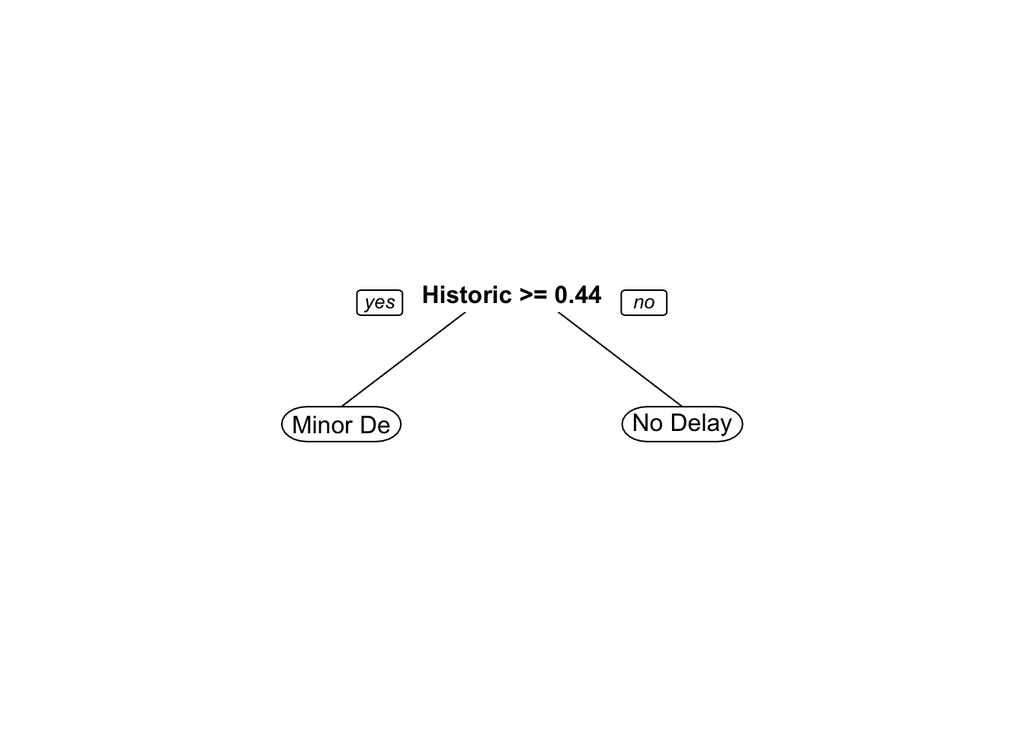

```r
prp(Airlines.cart)
```

```r
#What is the accuracy on the training set of a baseline model that predicts the most frequent outcome (No Delay) for all observations?
table(AirlinesTrain$DelayClass)
```

```
##
## Major Delay Minor Delay    No Delay
##        1118        2167        3282
```

```r
3282/nrow(AirlinesTrain)
```

```
## [1] 0.4997716
```

```r
#Make predictions on the training set, and then create a confusion matrix. What is the overall accuracy of the model?

TrainPred.rpart<- predict(Airlines.cart,newdata = AirlinesTrain,type = "class")
tbl <- table(AirlinesTrain$DelayClass, TrainPred.rpart)
TrainAcc<- sum(diag(tbl))/sum(tbl)
TrainAcc
```

```
## [1] 0.5261154
```

```r
#Make predictions on the testing set, and then create a confusion matrix. What is the overall accuracy of the model on the testing set?

TestPred.rpart<- predict(Airlines.cart,newdata = AirlinesTest,type = "class")
tbl <- table(AirlinesTest$DelayClass, TestPred.rpart)
TestAcc<- sum(diag(tbl))/sum(tbl)
TestAcc
```

```
## [1] 0.5167022
```

## Probelm 2. Predicting Sales on eBay

Individuals selling used items are often faced with a difficult choice – should they try to sell the items through a yard/estate sale, a consignment shop, an auction, or some other means? Often, this choice will come down to the convenience of selling the items, the price the items can fetch, and the speed with which the items can be sold.

To determine whether analytics can be used to help make this choice, we will look at whether data from previous auctions on eBay, a major online auction and shopping site, can be used to predict whether a new item will be sold at some target price. We will limit our attention to Christian Louboutin shoes, using data from nearly 4,000 auctions from late 2014. In this analysis, the dependent variable will be the binary outcome variable sold, which takes value 1 if the item was sold and 0 if it was not sold. We also include saleprice, which is the price the shoe sold at (NA for shoes that did not sell). For each item, the file ebay.csv contains the following independent variables:

```r
ebay<- read.csv("ebay.csv",stringsAsFactor = FALSE)
str(ebay)
```

```
## 'data.frame':    3796 obs. of  12 variables:
##  $ biddable   : int  1 0 1 1 0 1 1 1 0 1 ...
##  $ sold       : int  0 0 1 1 0 1 1 0 1 1 ...
##  $ startprice : num  199 375 300 50 89 ...
##  $ saleprice  : num  NA NA 780 561 NA ...
##  $ condition  : chr  "Pre-owned" "New with box" "Pre-owned" "Pre-owned" ...
##  $ size       : num  9.5 7.5 8.5 8.5 5.5 8.5 10 6.5 9 6.5 ...
##  $ heel       : chr  "Low" "High" "High" "High" ...
##  $ style      : chr  "Open Toe" "Slingback" "Pump" "Pump" ...
##  $ color      : chr  "Black" "Other/Missing" "Black" "Black" ...
##  $ material   : chr  "Suede" "Satin" "Other/Missing" "Snakeskin" ...
##  $ snippit    : chr  "Had soles re- covered." "" "" "" ...
##  $ description: chr  "Very good condition. Heel height very manageable. Low black" "From my own personal collection, great condition, and only tried on for 5 minutes around the house. They are size 37.5 but fit "| __truncated__ "With its staggering half-foot-high heel and chunky hidden platform, …
```

```r
#What proportion of all shoes were sold?
table(ebay$sold)
```

```
##
##    0    1
## 2997  799
```

```r
799/nrow(ebay)
```

```
## [1] 0.2104847
```

```r
#Which of the numerical variables has at least one missing value?
summary(ebay)
```

```
##     biddable           sold          startprice       saleprice
##  Min.   :0.0000   Min.   :0.0000   Min.   :   0.0   Min.   :   0.0
##  1st Qu.:0.0000   1st Qu.:0.0000   1st Qu.: 280.0   1st Qu.: 200.0
##  Median :1.0000   Median :0.0000   Median : 449.0   Median : 325.0
##  Mean   :0.5911   Mean   :0.2105   Mean   : 472.3   Mean   : 372.7
##  3rd Qu.:1.0000   3rd Qu.:0.0000   3rd Qu.: 600.0   3rd Qu.: 500.0
##  Max.   :1.0000   Max.   :1.0000   Max.   :4500.0   Max.   :3995.0
##                                                     NA's   :2997
##   condition              size            heel              style
##  Length:3796        Min.   : 4.000   Length:3796        Length:3796
##  Class :character   1st Qu.: 7.000   Class :character   Class :character
##  Mode  :character   Median : 8.000   Mode  :character   Mode  :character
##                     Mean   : 7.933
##                     3rd Qu.: 9.000
##                     Max.   :12.000
##                     NA's   :68
##     color             material           snippit
##  Length:3796        Length:3796        Length:3796
##  Class :character   Class :character   Class :character
##  Mode  :character   Mode  :character   Mode  :character
##
##
##
##
##  description
##  Length:3796
##  Class :character
##  Mode  :character
##
##
##
##
```

```r
#What is the most common shoe size in the dataset?
table(ebay$size)
```

```
##
##    4  4.5    5  5.5    6  6.5    7  7.5    8  8.5    9  9.5   10 10.5   11
##   14   28   87  154  264  356  402  413  442  385  397  298  235  139   79
## 11.5   12
##   21   14
```

```r
summary(ebay$size)
```

```
##    Min. 1st Qu.  Median    Mean 3rd Qu.    Max.    NA's
##   4.000   7.000   8.000   7.933   9.000  12.000      68
```

```r
# convert to factors
ebay[c("sold", "condition","heel","style","color","material")] <- lapply(ebay[c("sold", "condition","heel","style","color","material")], as.factor)

# splitting data
set.seed(144)
library(caTools)
spl = sample.split(ebay$sold,0.7)
ebayTrain <- subset(ebay,spl== T)
ebayTest <- subset(ebay,spl== F)

# logistic
ebay.glm<- glm(sold~biddable+startprice+condition+heel+style+color+material, data = ebayTrain,family = binomial)
summary(ebay.glm)
```

```
##
## Call:
## glm(formula = sold ~ biddable + startprice + condition + heel +
##     style + color + material, family = binomial, data = ebayTrain)
##
## Deviance Residuals:
##     Min       1Q   Median       3Q      Max
## -1.5805  -0.7022  -0.5002  -0.2166   5.9322
##
## Coefficients:
##                             Estimate Std. Error z value Pr(>|z|)
## (Intercept)                0.5990788  0.3285428   1.823 0.068236 .
## biddable                   0.0113984  0.1114610   0.102 0.918547
## startprice                -0.0044423  0.0003041 -14.607  < 2e-16 ***
## conditionNew with defects -0.2451855  0.3727966  -0.658 0.510736
## conditionNew without box  -0.2145965  0.2290351  -0.937 0.348780
## conditionPre-owned        -0.4952981  0.1374505  -3.603 0.000314 ***
## heelFlat                   0.1431346  0.6387994   0.224 0.822704
## heelHigh                   0.1224260  0.1340119   0.914 0.360955
## heelLow                   -2.5549302  1.0411255  -2.454 0.014127 *
## heelMedium                -0.5830418  0.2674958  -2.180 0.029285 *
## styleOther/Missing         0.5268920  0.2127852   2.476 0.013280 *
## stylePlatform             -0.1712048  0.2102085  -0.814 0.415386
## stylePump                  0.4683107  0.1817995   2.576 0.009996 **
## styleSlingback            -0.2294999  0.2535765  -0.905 0.365438
## styleStiletto              0.8325406  0.2606786   3.194 0.001404 **
## colorBlack                 0.2226547  0.1766847   1.260 0.207604
## colorBrown                -0.5252811  0.2982060  -1.761 0.078159 .
## colorOther/Missing        -0.2051389  0.1793759  -1.144 0.252779
## colorRed                  -0.1261035  0.2705234  -0.466 0.641111
## materialOther/Missing     -0.2192565  0.1531385  -1.432 0.152214
## materialPatent Leather     0.0809572  0.1431549   0.566 0.571719
## materialSatin             -1.1078098  0.3153264  -3.513 0.000443 ***
## materialSnakeskin          0.1562727  0.3444677   0.454 0.650070
## materialSuede             -0.0713244  0.1789439  -0.399 0.690199
## ---
## Signif. codes:  0 '***' 0.001 '**' 0.01 '*' 0.05 '.' 0.1 ' ' 1
##
## (Dispersion parameter for binomial family taken to be 1)
##
##     Null deviance: 2733.9  on 2656  degrees of freedom
## Residual deviance: 2372.7  on 2633  degrees of freedom
## AIC: 2420.7
##
## Number of Fisher Scoring iterations: 5
```

```r
# test probability for the first case of training set
ebayTrainPred.glm <- predict(ebay.glm, newdata = ebayTrain, type = "response")
# test probability
coeff<- unname(coef(ebay.glm)[c("(Intercept)","biddable","startprice", "conditionPre-owned", "heelLow", "styleOpen Toe", "colorBlack", "materialSuede")])
coeff
```

```
## [1]  0.599078822  0.011398447 -0.004442331 -0.495298063 -2.554930231
## [6]           NA  0.222654724 -0.071324401
```

```r
value<- c(1,1,199,1,1,1,1,1)
value
```

```
## [1]   1   1 199   1   1   1   1   1
```

```r
z<- sum(coeff *value,na.rm=T)
z
```

```
## [1] -3.172444
```

```r
p <-  1/(1+exp(-1*z))
p
```

```
## [1] 0.04021596
```

```r
# Problem 7
coeff<- unname(coef(ebay.glm)[c("(Intercept)","biddable","startprice", "conditionPre-owned", "heelHigh", "styleOpen Toe", "colorBlack", "materialSatin")])
coeff
```

```
## [1]  0.599078822  0.011398447 -0.004442331 -0.495298063  0.122426050
## [6]           NA  0.222654724 -1.107809837
```

```r
value<- c(1,0,100,1,1,1,1,1)
value
```

```
## [1]   1   0 100   1   1   1   1   1
```

```r
z<- sum(coeff *value,na.rm=T)
z
```

```
## [1] -1.103181
```

```r
p <- 1/(1+exp(-1*z))
p
```

```
## [1] 0.2491443
```

```r
odds <- exp(z)
odds
```

```
## [1] 0.3318138
```

```r
# odds for styleStiletto
coeff<- unname(coef(ebay.glm)[c("(Intercept)","biddable","startprice", "conditionPre-owned", "heelHigh", "styleStiletto", "colorBlack", "materialSatin")])
value<- c(1,0,100,1,1,1,1,1)
z<- sum(coeff *value,na.rm=T)
odds <- exp(z)
odds
```

```
## [1] 0.7628905
```

```r
# average
averageOdds<- mean(c(0.3318138,0.7628905,0.5619798,0.2796025,0.530004,0.2637691))
averageOdds
```

```
## [1] 0.4550099
```

```r
# Test set prediction
ebayTestPred.glm <- predict(ebay.glm, newdata = ebayTest, type = "response")
table(ebayTest$sold, ebayTestPred.glm>=0.5)
```

```
##
##     FALSE TRUE
##   0   877   22
##   1   182   58
```

```r
#On how many test set observations does your logistic regression model make a different prediction than the prediction the naive baseline model would make?
table(ebayTest$sold)
```

```
##
##   0   1
## 899 240
```

```r
table(as.numeric(ebayTestPred.glm>=0.5)==0)
```

```
##
## FALSE  TRUE
##    80  1059
```

```r
library(ROCR)
ROC.glm <- prediction(ebayTestPred.glm, ebayTest$sold, label.ordering = NULL)
auc.glm <- as.numeric(performance(ROC.glm, "auc")@y.values)
auc.glm
```

```
## [1] 0.7444244
```

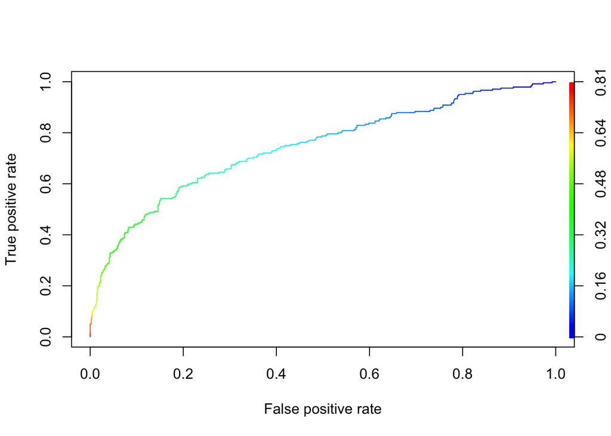

```r
roc.perf = performance(ROC.glm,measure = "tpr",x.measure = "fpr")
plot(roc.perf,colorize=TRUE)

set.seed(144)
library(caret)
```

```r
library(e1071)
tr.control <- trainControl(method = "cv", number = 10)
cp.grid <- expand.grid(.cp = seq(0.001,0.05,0.001))
tr = train(sold~biddable+startprice+condition+heel+style+color+material, data = ebayTrain, method = "rpart", trControl = tr.control, tuneGrid = cp.grid)
tr
```

```
## CART
##
## 2657 samples
##   11 predictor
##    2 classes: '0', '1'
##
## No pre-processing
## Resampling: Cross-Validated (10 fold)
##
## Summary of sample sizes: 2391, 2392, 2391, 2392, 2391, 2392, ...
##
## Resampling results across tuning parameters:
##
##   cp     Accuracy   Kappa      Accuracy SD  Kappa SD
##   0.001  0.8080579  0.2921578  0.02055476   0.07403495
##   0.002  0.8140828  0.2850896  0.02008198   0.07844282
##   0.003  0.8163371  0.2831055  0.02102088   0.08051920
##   0.004  0.8182168  0.2789793  0.01800472   0.08058645
##   0.005  0.8201050  0.2823283  0.01976383   0.08763543
##   0.006  0.8189800  0.2793326  0.02093953   0.09387458
##   0.007  0.8197319  0.2833390  0.02168394   0.09794084
##   0.008  0.8204781  0.2765420  0.02207501   0.10955497
##   0.009  0.8193503  0.2741764  0.02344067   0.11141616
##   0.010  0.8185984  0.2660880  0.02355390   0.11195554
##   0.011  0.8185984  0.2660880  0.02355390   0.11195554
##   0.012  0.8163342  0.2504377  0.02127912   0.09582560
##   0.013  0.8155824  0.2515450  0.02143279   0.09542533
##   0.014  0.8148248  0.2561205  0.02049042   0.07984224
##   0.015  0.8148248  0.2575012  0.02049042   0.07943305
##   0.016  0.8151993  0.2553336  0.01985899   0.07973557
##   0.017  0.8151993  0.2553336  0.01985899   0.07973557
##   0.018  0.8151993  0.2553336  0.01985899   0.07973557
##   0.019  0.8151993  0.2553336  0.01985899   0.07973557
##   0.020  0.8151993  0.2553336  0.01985899   0.07973557
##   0.021  0.8151993  0.2553336  0.01985899   0.07973557
##   0.022  0.8151993  0.2553336  0.01985899   0.07973557
##   0.023  0.8151993  0.2553336  0.01985899   0.07973557
##   0.024  0.8140715  0.2559006  0.01868389   0.08047596
##   0.025  0.8140715  0.2559006  0.01868389   0.08047596
##   0.026  0.8133196  0.2571106  0.01925396   0.07943980
```

[output cut: 12 more lines]

```
##   0.039  0.8095602  0.2141526  0.01589717   0.05357068
##   0.040  0.8095602  0.2141526  0.01589717   0.05357068
##   0.041  0.8095602  0.2141526  0.01589717   0.05357068
##   0.042  0.8095602  0.2141526  0.01589717   0.05357068
##   0.043  0.8095602  0.2141526  0.01589717   0.05357068
##   0.044  0.8103121  0.2082953  0.01540696   0.05818034
##   0.045  0.8103121  0.2082953  0.01540696   0.05818034
##   0.046  0.8103121  0.2082953  0.01540696   0.05818034
##   0.047  0.8103121  0.2082953  0.01540696   0.05818034
##   0.048  0.8042971  0.1666286  0.01657443   0.10534456
##   0.049  0.7990240  0.1282940  0.01636169   0.12442817
##   0.050  0.7990240  0.1282940  0.01636169   0.12442817
##
## Accuracy was used to select the optimal model using  the largest value.
## The final value used for the model was cp = 0.008.
```

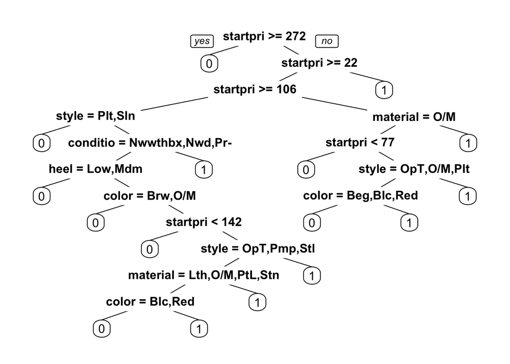

```r
ebayTrain.cart <- rpart(sold ~ biddable+startprice+condition+heel+style+color+material, data = ebayTrain, method = "class", cp = 0.004)
prp(ebayTrain.cart)
```

```r
#summary(ebayTrain.cart)

# text analytics
library(tm)
corpus <- Corpus(VectorSource(ebay$description))
corpus <- tm_map(corpus,tolower)
corpus <- tm_map(corpus, PlainTextDocument)
corpus<- tm_map(corpus, removePunctuation)
corpus <- tm_map(corpus, removeWords, stopwords("english"))
corpus <- tm_map(corpus, stemDocument)
dtm<- DocumentTermMatrix(corpus)
dtm
```

```
## <<DocumentTermMatrix (documents: 3796, terms: 10530)>>
## Non-/sparse entries: 256745/39715135
## Sparsity           : 99%
## Maximal term length: 1651
## Weighting          : term frequency (tf)
```

```r
spdtm<- removeSparseTerms(dtm, 0.8)
spdtm
```

```
## <<DocumentTermMatrix (documents: 3796, terms: 57)>>
## Non-/sparse entries: 73772/142600
## Sparsity           : 66%
## Maximal term length: 9
## Weighting          : term frequency (tf)
```

```r
#Convert spdtm to a data frame called descriptionText. Which word stem appears the most frequently across all descriptions?
descriptionText<- as.data.frame(as.matrix(spdtm))
which.max(colSums(descriptionText))
```

```
## ship
##   45
```

```r
# names(descript)
names(descriptionText) <- paste0("D",names(descriptionText))

#Copy the following variables from the eBay data frame into descriptionText:

variables<- c("sold","biddable","startprice","condition","heel","style","color","material")
descriptionText[,variables] <- ebay[,variables]

#Then, split descriptionText into a training set called trainText and a testing set called testText using the variable "spl" that was earlier used to split eBay into train and test.
trainText<- subset(descriptionText,spl==T)
testText<- subset(descriptionText,spl==F)

#How many variables are in testText?
ncol(testText)
```

```
## [1] 65
```

```r
# Using trainText, train a logistic regression model called glmText
glmText<- glm(sold~.,data = trainText,family = binomial)
summary(glmText)
```

```
##
## Call:
## glm(formula = sold ~ ., family = binomial, data = trainText)
##
## Deviance Residuals:
##     Min       1Q   Median       3Q      Max
## -2.1575  -0.6792  -0.4639  -0.1812   5.9106
##
## Coefficients:
##                             Estimate Std. Error z value Pr(>|z|)
## (Intercept)                0.5768386  0.3643233   1.583  0.11335
## D100                       0.1333236  0.0935775   1.425  0.15423
## Daccept                    0.0462693  0.1185104   0.390  0.69622
## Dask                      -0.2551926  0.1454337  -1.755  0.07931 .
## Dauction                  -0.0956112  0.0840587  -1.137  0.25536
## Dauthent                  -0.0733045  0.0695524  -1.054  0.29191
## Dbag                      -0.0773114  0.1523268  -0.508  0.61178
## Dbid                      -0.0593072  0.0674848  -0.879  0.37950
## Dblack                     0.0653284  0.0928073   0.704  0.48149
## Dbox                      -0.0603242  0.0730560  -0.826  0.40896
## Dbrand                    -0.1421362  0.1216159  -1.169  0.24251
## Dbuyer                     0.0102474  0.0802397   0.128  0.89838
## Dchristian                 0.0310198  0.0989755   0.313  0.75397
## Dcolor                     0.0013237  0.1061454   0.012  0.99005
## Dcome                      0.0090456  0.1023810   0.088  0.92960
## Dcondit                   -0.1503873  0.0724701  -2.075  0.03797 *
## Dcontact                   0.1632715  0.0992649   1.645  0.10001
## Dday                       0.0182653  0.1001301   0.182  0.85526
## Ddust                      0.0194057  0.1760285   0.110  0.91222
## Dfree                     -0.1411326  0.0942576  -1.497  0.13431
## Dguarante                  0.2910171  0.1203271   2.419  0.01558 *
## Dheel                      0.0109644  0.0518710   0.211  0.83259
## Dinclud                    0.1530466  0.1044354   1.465  0.14279
## Dinsol                    -0.0787667  0.1099257  -0.717  0.47366
## Dintern                    0.1631924  0.0934936   1.745  0.08090 .
## Ditali                     0.0188237  0.1808631   0.104  0.91711
## Ditem                      0.0207542  0.0366502   0.566  0.57120
## Dleather                   0.0654216  0.0600783   1.089  0.27618
## Dlook                     -0.1774397  0.1185220  -1.497  0.13437
## Dlouboutin                -0.0361439  0.0877012  -0.412  0.68025
```

[output cut: 46 more lines]

```
## materialOther/Missing     -0.1151685  0.1675299  -0.687  0.49180
## materialPatent Leather     0.0649683  0.1793239   0.362  0.71713
## materialSatin             -1.1009573  0.3269934  -3.367  0.00076 ***
## materialSnakeskin          0.2769910  0.3592242   0.771  0.44066
## materialSuede              0.0055386  0.1909046   0.029  0.97685
## ---
## Signif. codes:  0 '***' 0.001 '**' 0.01 '*' 0.05 '.' 0.1 ' ' 1
##
## (Dispersion parameter for binomial family taken to be 1)
##
##     Null deviance: 2733.9  on 2656  degrees of freedom
## Residual deviance: 2255.9  on 2576  degrees of freedom
## AIC: 2417.9
##
## Number of Fisher Scoring iterations: 5
```

```r
#How many of the word frequencies from the description text (variables beginning with the letter "D") are significant at or below the p=0.05 level?

table(coef(summary(glmText))[,4][2:146]<=0.05)
```

```
##
## FALSE  TRUE
##    66    14
```

```r
# What is the training-set AUC of the new logistic regression model?

glmText.pred <- predict(glmText,newdata = trainText, type = "response")
rocText<- prediction(glmText.pred, trainText$sold)
aucTrain <- as.numeric(performance(rocText,"auc")@y.values)
aucTrain
```

```
## [1] 0.7773333
```

```r
#What is the test-set AUC of the new logistic regression model?
glmText.pred <- predict(glmText,newdata = testText, type = "response")
rocText<- prediction(glmText.pred, testText$sold)
aucTest<- as.numeric(performance(rocText,"auc")@y.values)
aucTest
```

```
## [1] 0.7356229
```

## Problem 3. Understanding Customers of Hubway

In Unit 6, we saw how clustering can be used for market segmentation, the idea of dividing a broad target market of customers into smaller, more similar groups, and then designing a marketing strategy specifically for each group. In this problem, we’ll see how the same idea can be applied using data from Hubway, a bike-sharing program in the Boston, Massachusetts area.

Registered users of Hubway can check-out a bicycle from one of 140 stations located throughout the Metro-Boston area, and return the bike to any of the 140 stations. This enables users to take bikes on one-way trips throughout the city. Users pay a membership fee, which includes unlimited trips up to 30 minutes in duration at no additional cost. Trips longer than 30 minutes cost additional “overtime” fees.

In this problem, we’ll use the dataset HubwayTrips.csv, which contains data from trips taken by registered users of Hubway from June 2012 through September 2012. The dataset contains the following seven variables:

```r
Hubway<-read.csv("HubwayTrips.csv")
str(Hubway)
```

```
## 'data.frame':    185190 obs. of  7 variables:
##  $ Duration : int  212 229 259 273 279 291 295 298 298 303 ...
##  $ Morning  : int  0 0 0 0 0 0 0 0 0 0 ...
##  $ Afternoon: int  1 1 0 1 1 1 1 1 1 1 ...
##  $ Evening  : int  0 0 1 0 0 0 0 0 0 0 ...
##  $ Weekday  : int  1 1 0 1 1 1 1 1 1 1 ...
##  $ Male     : int  1 1 0 1 0 1 1 0 0 1 ...
##  $ Age      : int  17 17 17 17 17 17 17 17 17 17 ...
```

```r
#What is the average duration (in seconds) of all trips in this dataset?

mean(Hubway$Duration)
```

```
## [1] 721.551
```

```r
#What is the average duration (in seconds) of trips taken on the weekdays?
mean(Hubway$Duration[Hubway$Weekday==1])
```

```
## [1] 700.0921
```

```r
# What is the average duration (in seconds) of trips taken on the weekends?
mean(Hubway$Duration[Hubway$Weekday==0])
```

```
## [1] 826.2457
```

```r
#How many trips were taken in the morning?
table(Hubway$Morning)
```

```
##
##      0      1
## 124791  60399
```

```r
#How many trips were taken in the afternoon?
table(Hubway$Afternoon)
```

```
##
##      0      1
## 111169  74021
```

```r
#How many trips were taken in the evening?
table(Hubway$Evening)
```

```
##
##      0      1
## 138926  46264
```

```r
#In this dataset, what proportion of trips are taken by male users?
table(Hubway$Male)
```

```
##
##      0      1
##  48685 136505
```

```r
136506/nrow(Hubway)
```

```
## [1] 0.7371132
```

```r
# normalize the variables
library(caret)
preproc <- preProcess(Hubway)
HubwayNorm <- predict(preproc,Hubway)

#What is the maximum value of Duration in the normalized dataset?

max(HubwayNorm$Duration)
```

```
## [1] 67.46504
```

```r
#What is the maximum value of Age in the normalized dataset?
max(HubwayNorm$Age)
```

```
## [1] 3.877016
```

```r
#Run the k-means clustering algorithm on your normalized dataset, selecting 10 clusters.
set.seed(5000)
KMC = kmeans(HubwayNorm, centers = 10)
HubKMC = KMC$cluster
sort(table(HubKMC))
```

```
## HubKMC
##     5    10     4     8     9     7     3     6     1     2
##  9720  9899 10819 14981 15635 16067 20256 22931 28473 36409
```

```r
#Which cluster best fits the description "trips taken by female users on weekday evenings"?
table(Hubway$Male ==0 & Hubway$Weekday==1 & Hubway$Evening==1)
```

```
##
##  FALSE   TRUE
## 175432   9758
```

```r
tapply(Hubway$Male, KMC$cluster, mean)
```

```
##          1          2          3          4          5          6
## 1.00000000 0.68851108 1.00000000 0.97347259 0.74763374 0.82852907
##          7          8          9         10
## 0.00000000 0.67926040 1.00000000 0.01000101
```

```r
tapply(Hubway$Weekday, KMC$cluster, mean)
```

```
##         1         2         3         4         5         6         7
## 1.0000000 1.0000000 0.8307662 0.9095110 0.0000000 0.9968165 0.8568494
##         8         9        10
## 0.0000000 1.0000000 0.9979796
```

```r
tapply(Hubway$Evening, KMC$cluster, mean)
```

```
##          1          2          3          4          5          6
## 1.00000000 0.00000000 0.00000000 0.00018486 0.81975309 0.00000000
##          7          8          9         10
## 0.00000000 0.00000000 0.00000000 0.99212042
```

```r
#Now, use the cluster assignments from k-means clustering together with the cluster centroids to answer the next few questions.

#Which cluster best fits the description "leisurely (longer than average) afternoon trips taken on the weekends"?

set1<-which(tapply(Hubway$Duration, KMC$cluster, mean) > mean(Hubway$Duration))
set2<- which(tapply(Hubway$Weekday, KMC$cluster, mean) < 0.5)
set3<- which(tapply(Hubway$Afternoon, KMC$cluster, mean) > 0.5)
intersect(intersect(set1,set2),set3)
```

```
## [1] 8
```

```r
#Which cluster best fits the description "morning trips taken by older male users"?

set1<-which(tapply(Hubway$Age, KMC$cluster, mean) > mean(Hubway$Age))
set2<- which(tapply(Hubway$Male, KMC$cluster, mean) > 0.5)
set3<- which(tapply(Hubway$Morning, KMC$cluster, mean) > 0.5)
intersect(intersect(set1,set2),set3)
```

```
## [1] 4 9
```

```r
set.seed(8000)
KMC = kmeans(HubwayNorm, centers = 20)
HubKMC = KMC$cluster
sort(table(HubKMC))
```

```
## HubKMC
##    20     2     1     6     8    17    15    18     7    10    12    16
##    99   330  1897  2759  4432  4784  4949  6596  7295  7826  7922  9019
##     3     9    19     5     4    13    14    11
##  9033 10246 11064 14226 14991 21215 21282 25225
```

```r
#Which clusters can be described as "shorter than average trips that occur on weekday evenings"?

set1<-which(tapply(Hubway$Duration, KMC$cluster, mean) < mean(Hubway$Duration))
set2<- which(tapply(Hubway$Weekday, KMC$cluster, mean) > 0.5)
set3<- which(tapply(Hubway$Evening, KMC$cluster, mean) > 0.5)

intersect(intersect(set1,set2),set3)
```

```
## [1]  7 13
```